# Задачи по Эконометрике-2: ROC-кривая

Н.В. Артамонов (МГИМО МИД России)

# 1 Пример ROC

## 1.1 Labour force equation

Для датасета [mroz_Greene](http://www.stern.nyu.edu/~wgreene/Text/Edition7/TableF5-1.csv) рассморим probit-регрессии:

- **LFP на WA, WA^2, WE, KL6, K618, CIT, UN, log(FAMINC)**,
- **LFP на CIT, UN**
- **LFP на const**

Их ROC-кривые

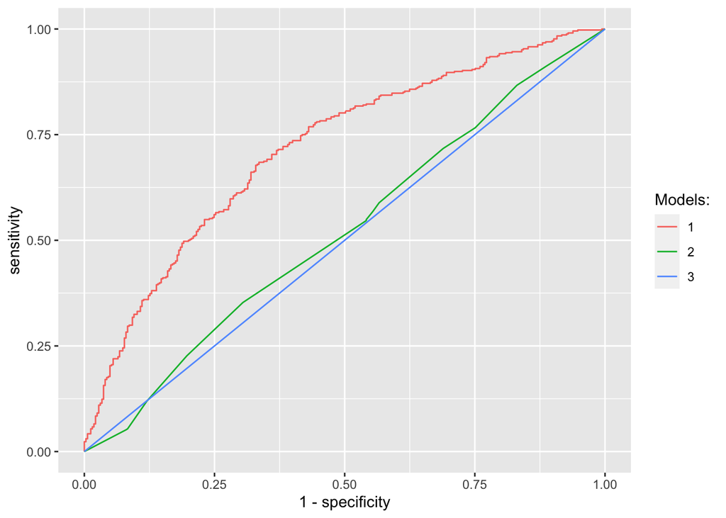

Показатели AUC

```
============
Модель  AUC
------------
1      0.716
2      0.520
3      0.500
------------
```

Значимость регрессий 1 & 2 (LR-тест)

```
====================
Модель  Stat   p.val
--------------------
1      105.066   0
2       0.620  0.733
--------------------
```

# 2 ROC для сравнения моделей

## 2.1 Labour force equations

Для датасета [mroz_Greene](http://www.stern.nyu.edu/~wgreene/Text/Edition7/TableF5-1.csv) рассморим logit-регрессии:

- **LFP на WA, WA^2, WE, KL6, K618, CIT, UN, log(FAMINC)**,
- **LFP на WE, KL6, K618, CIT, UN, log(FAMINC)**
- **LFP на K618, CIT, UN, log(FAMINC)**
- **LFP на WA, WA^2, KL6, K618, CIT, UN, log(FAMINC)**
- **LFP на const**

Их ROC-кривые

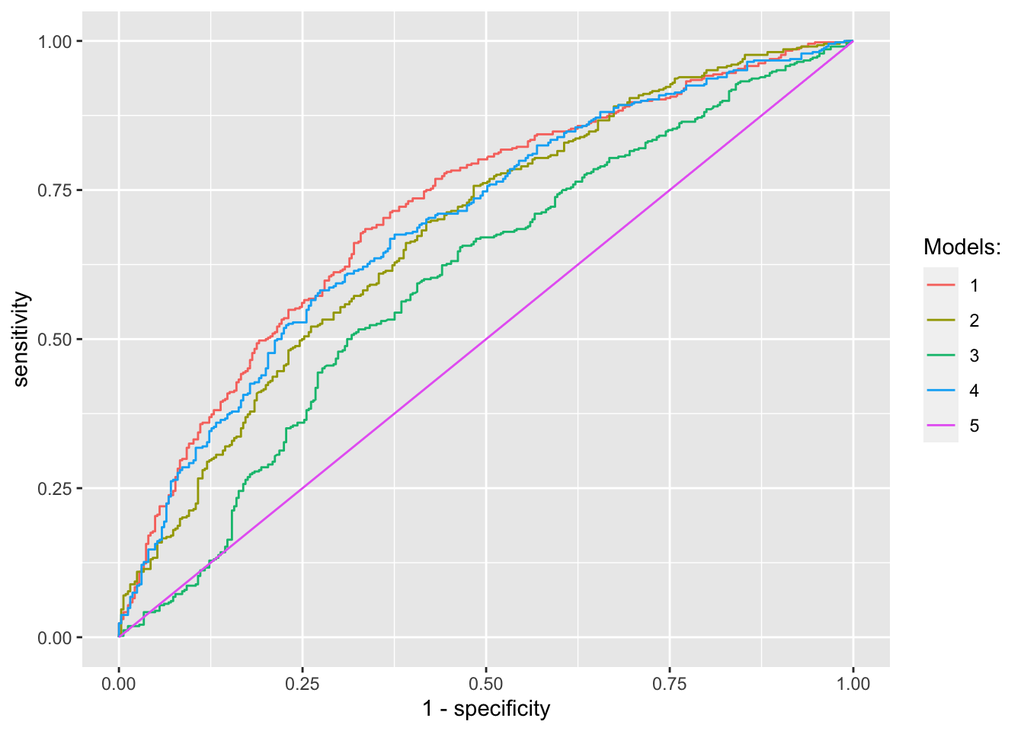

Показатели AUC

```
============
Модель  AUC
------------
1      0.716
2      0.680
3      0.599
4      0.694
5      0.500
------------
```

## 2.2 Labour force equation (LPM, logit, probit)

Для датасета [mroz_Greene](http://www.stern.nyu.edu/~wgreene/Text/Edition7/TableF5-1.csv) рассморим регрессию **LFP на WA, WA^2, WE, KL6, K618, CIT, UN, log(FAMINC)** трёх спецификаций

- probit
- logit
- LPM

Их ROC-кривые

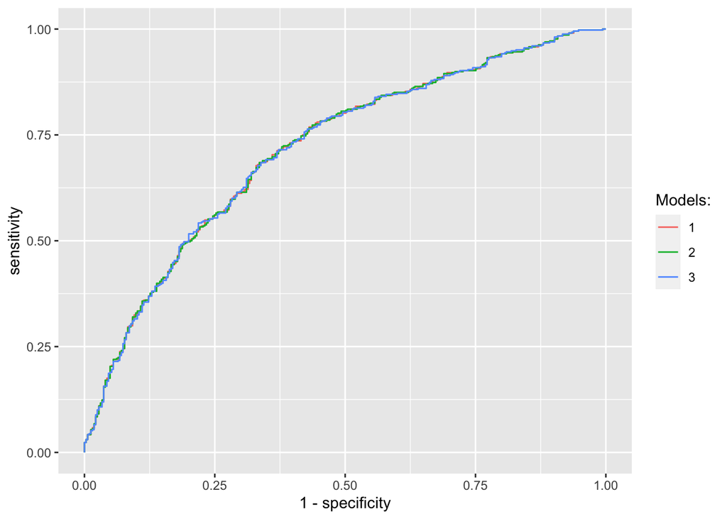

Показатели AUC

```
=============
Модель  AUC
-------------
1      0.7159
2      0.7160
3      0.7155
-------------
```

## 2.3 approve equations

Для датасета `loanapp` рассморим logit-регрессии:

- **approve на appinc/100, (appinc/100)^2, mortno, unem, dep, yjob, self**,
- **approve на mortno, unem, dep, yjob, self**
- **approve на appinc/100, (appinc/100)^2, mortno, unem, dep**
- **approve на yjob, self**
- **approve на const**

Их ROC-кривые

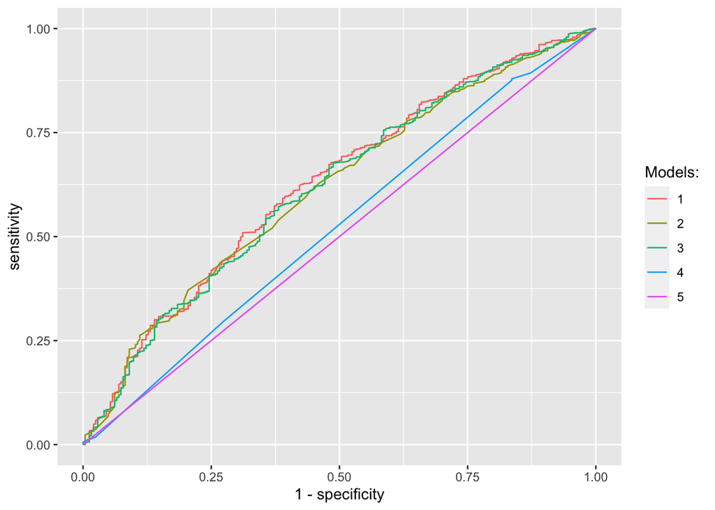

Показатели AUC

```
============
Модель  AUC
------------
1      0.627
2      0.615
3      0.618
4      0.522
5      0.500
------------
```